# DS202A: Data Science for Social Scientists

Group 8: What Actions Can Be Justified? Are There Regional Differences When It Comes to This?

# 1. What Actions Can Be Justified?

## 1.1 Introduction

To answer this research question, we explored and analysed data from the seventh wave of the World Values Survey (WVS). The WVS is an international research endeavour committed to the scientific investigation of values - “social, political, economic, religious, and cultural” - the purpose being to ascertain their temporal stability and impact on societal development (World Values Survey n.d.) (Inglehart et al. 2021). These values are investigated in five year waves, primarily using a “representative comparative social survey” (World Values Survey n.d.). The methodological rigour of the survey design and delivery decreases the probability of suspicion, framing effects, and biases from respondents (Torgler and Schneider 2005; Torgler and Valev 2010). Accordingly, the WVS is globally implemented and recognised in academia and policy, having generated thousands of publications and citations, and been employed by governments and organisations worldwide, including the World Health Organisation and the United Nations (World Values Survey n.d.).

Between 2017 and 2022, 64 surveys were completed on representative, random probability samples of each country’s adult population (Inglehart et al. 2021; Martínez, Sánchez, and Galindo 2022), mostly between 2018-2020 using face-to-face interviews (World Values Survey n.d.). This generated a detailed dataset (Haerpfer et al. 2022) of considerable “geographical and thematic scope”, encompassing 94.5% of the global population and a wide variety of social scientific disciplines (World Values Survey n.d.).

The research question *what actions can be justified?* is in reference to the actions listed in questions 177 to 195 of the WVS. The actions of interest range from seemingly minor indiscretions, such as avoiding a fare on public transport, to more serious offences like bribery, violence, terrorism, and controversial bioethical issues including abortion, euthanasia, and capital punishment. Acceptability, or justifiability, of such actions will likely vary cross-culturally as the “norms, values, and belief systems” regarding right and wrong differ between cultures (Lee et al. 2004), perhaps due to religious and political ideology, family values, economic status, education level, and other individual, social, economic, and cultural factors. Section 1 of the report will investigate how justifiability of the specified actions can be calculated in answer to the first research question.

**RStudio Setup** (importing packages and libraries)

```r
library('tidyverse')
library('plotly')
library('tidymodels')
library('moments')
library('car')
library('knitr')
library('kableExtra')
library('dendextend')
library('reshape2')
library('philentropy') # for Jensen-Shannon divergence
library('e1071')       # for skew
library('factoextra')  # for elbow and average silhouette plots
library('dbscan')      # library for DBSCAN
library('ggrepel')
library('parallel') # parallel processing
library('doParallel')
library('corrplot')

# Maps
library('maps')
library('countrycode')
library('rnaturalearth')
library('rnaturalearthdata')

# prediction models
library('rpart.plot')

library('magrittr')
```

## 1.2 Loading and Cleaning Data

```r
wvs <- read.csv(unz("WVS.csv.zip",
                     "WVS.csv"))
```

### Selecting Relevant Variables

```r
# Select relevant demographics columns
dem_cols <- c("B_COUNTRY", "B_COUNTRY_ALPHA", "N_REGION_ISO", "N_REGION_WVS", "G_TOWNSIZE2", "H_SETTLEMENT", "H_URBRURAL", "O1_LONGITUDE", "O2_LATITUDE")

# Independent variables
ind_vars <- c("Q1", "Q2", "Q3", "Q4", "Q5", "Q6", "Q260", "X003R2", "Q269", "Q274", "Q275R", "Q287", "Q289")

# Select questions
wvs_qs <- wvs %>%
  select(all_of(dem_cols), all_of(ind_vars), Q177:Q195)

# Add country_name column for interpretability
wvs_qs <- wvs_qs %>%
  mutate(country_name = case_when(
    B_COUNTRY_ALPHA == "NIR" ~ "Northern Ireland",
    B_COUNTRY_ALPHA == "GBR" ~ "Great Britain", # Resolve GBR/UK/NI disparity
    TRUE ~ countrycode(B_COUNTRY_ALPHA,
                      origin = 'iso3c',
                      destination = 'country.name')
  )) %>%
  relocate(country_name)

head(wvs_qs) %>%
  kable()
```

| country_name | B_COUNTRY | B_COUNTRY_ALPHA | N_REGION_ISO | N_REGION_WVS | G_TOWNSIZE2 | H_SETTLEMENT | H_URBRURAL | O1_LONGITUDE | O2_LATITUDE | Q1 | Q2 | Q3 | Q4 | Q5 | Q6 | Q260 | X003R2 | Q269 | Q274 | Q275R | Q287 | Q289 | Q177 | Q178 | Q179 | Q180 | Q181 | Q182 | Q183 | … |
| --- | --- | --- | --- | --- | --- | --- | --- | --- | --- | --- | --- | --- | --- | --- | --- | --- | --- | --- | --- | --- | --- | --- | --- | --- | --- | --- | --- | --- | --- | --- |
| Andorra | 20 | AND | 20007 | 20005 | 3 | 1 | 1 | 1.52 | 42.51 | 1 | 1 | 1 | 3 | 1 | 4 | 2 | 3 | 2 | 2 | 2 | 3 | 1 | 1 | 1 | 1 | 1 | 1 | 4 | 3 | … |
| Andorra | 20 | AND | 20003 | 20002 | 2 | 2 | 1 | 1.53 | 42.51 | 1 | 1 | 1 | 4 | 1 | 4 | 1 | 2 | 1 | 0 | 3 | 2 | 1 | 1 | 1 | 1 | 1 | 1 | 9 | 5 | … |
| Andorra | 20 | AND | 20003 | 20002 | 2 | 2 | 1 | 1.58 | 42.53 | 1 | 2 | 2 | 2 | 3 | 3 | 1 | 2 | 2 | 0 | 3 | 3 | 1 | 1 | 1 | 1 | 1 | 1 | 10 | 6 | … |
| Andorra | 20 | AND | 20003 | 20002 | 2 | 2 | 1 | 1.58 | 42.53 | 1 | 1 | 1 | 4 | 2 | 4 | 2 | 3 | 2 | 1 | 1 | 4 | 0 | 1 | 1 | 1 | 1 | 1 | 6 | 6 | … |
| Andorra | 20 | AND | 20003 | 20002 | 2 | 2 | 1 | 1.58 | 42.54 | 1 | 1 | 1 | 3 | 1 | 3 | 1 | 2 | 2 | 0 | 1 | 4 | 0 | 1 | 1 | 1 | 1 | 1 | 8 | 6 | … |
| Andorra | 20 | AND | 20006 | 20006 | 2 | 2 | 1 | 1.52 | 42.50 | 1 | 3 | 1 | 4 | 1 | 3 | 2 | 3 | 2 | 3 | 1 | 4 | 1 | 10 | 10 | 1 | 1 | 1 | 10 | 1 | … |

We select the relevant question numbers for our analysis, Q177:Q195, along with a range of demographic columns to retain the country specific identifiers and geographic information, along with a set of independent variables for prediction in section 2.4. We also retrieve individual country names for ease of interpretation.

### Cleaning Data

In the data, `N/A` and “Don’t Know” responses are coded as -1, -2, -3, and -5. We have decided to replace all instances of these integers with `N/A` for analysis, as to engage in imputation could introduce potential biases and assumptions that do not accurately reflect respondents. The World Values Survey (WVS) captures a broad range of cultural, societal, and individual perspectives across multiple countries, and these coded responses often reflect uncertainty or lack of knowledge, rather than missing data. Imputing these values could distort the true views of respondents, especially considering the complexity of factors such as national contexts, individual belief systems, and social influences (e.g. the importance of family or religion). Each country may have different interpretations, weights, or legislation regarding certain issues, and so imputing these values could mask regional or demographic differences, necessary for the next part of our analysis – “2. Are There Regional Differences When It Comes to This?”. By rendering these responses as null, we allow for a more accurate representation of the diverse worldviews reflected in the WVS data, ensuring our analysis remains grounded in actual responses provided by participants.

```r
# replace with N/A
wvs_qs <- wvs_qs %>%
  mutate(across(starts_with("Q"),
                ~if_else(. >= 1 & . <= 10, ., NA_real_)))
```

### Creating Question Labels

Aids graphical visualisation as there are 19 actions, and using question numbers may lead to confusion.

```r
question_labels <- c(
    "Q177" = "Claiming Unentitled Benefits",
    "Q178" = "Avoiding Transport Fare",
    "Q179" = "Stealing Property",
    "Q180" = "Tax Cheating",
    "Q181" = "Accepting Bribe",
    "Q182" = "Homosexuality",
    "Q183" = "Prostitution",
    "Q184" = "Abortion",
    "Q185" = "Divorce",
    "Q186" = "Sex Before Marriage",
    "Q187" = "Suicide",
    "Q188" = "Euthanasia",
    "Q189" = "Wife Beating",
    "Q190" = "Child Beating",
    "Q191" = "Violence Against Others",
    "Q192" = "Terrorism",
    "Q193" = "Casual Sex",
    "Q194" = "Political Violence",
    "Q195" = "Death Penalty")
```

**Converting the WVS to Long Format** (for analysis)

```r
wvs_long <- wvs_qs %>%
  pivot_longer(cols = Q177:Q195, names_to = "question", values_to="response")

# adding question labels
wvs_long <- wvs_long %>%
  mutate(question_label = question_labels[question])
```

## 1.3 Exploring Measures of Difference

### Descriptive Statistics

To understand justification differences across all actions outlined in the World Values Survey, we begin by exploring descriptive statistics. Since survey responses are recorded on an ordinal scale from 1 (‘Never Justifiable’) to 10 (‘Always Justifiable’), descriptive statistics help summarize the data effectively and facilitate comparisons between questions that elicit similar response patterns.

#### The Arithmetic Mean: The Central Tendency or Average

- The mean can tell us the average justification score in a country, and for each question
- A higher mean (closer to 10) would suggest that respondents generally justify the action.
- A lower mean (closer to 1) would indicate the action is generally unjustifiable.
- If we compare means, we could show which behaviors are more widely accepted or condemned, and comparison across countries can reveal regional moral differences.

**Arithmetic Mean**

```r
# compute the mean for each question
mean_data <- wvs_qs %>%
  select(Q177:Q195) %>%
  summarise(across(everything(), mean, na.rm = TRUE))

# convert to long format for plotting
mean_long <- mean_data %>%
  pivot_longer(cols = everything(), names_to = "question", values_to = "mean")
```

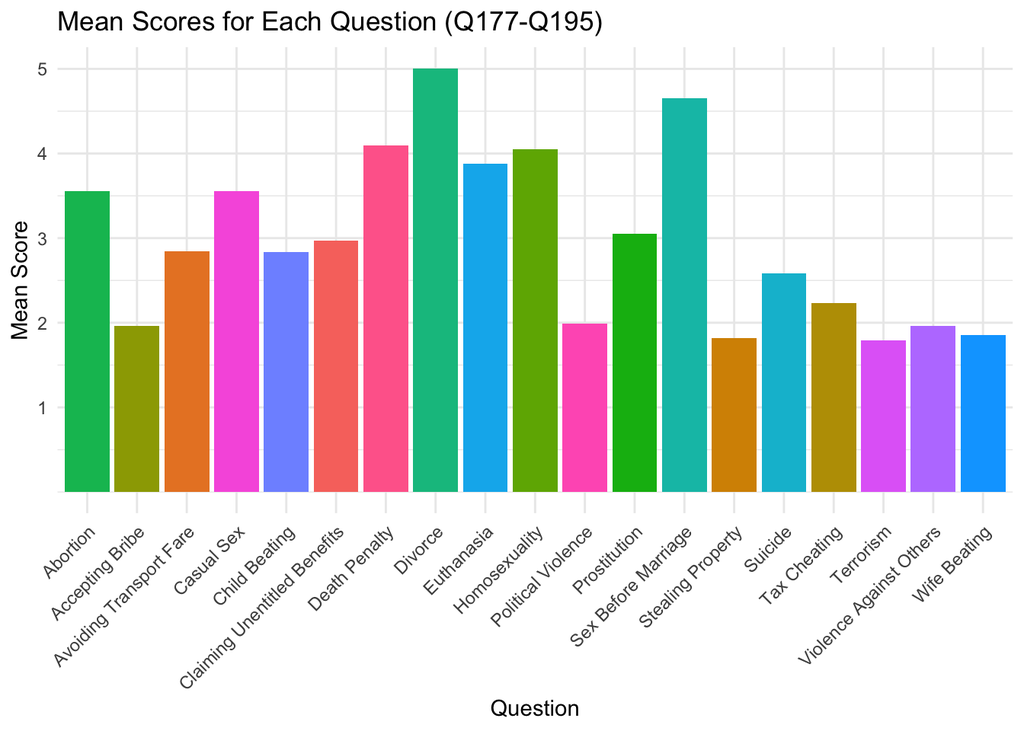

**Why Might We Hesitate to Use the Mean?**

- The mean is sensitive to outliers, and if some respondents provide responses at the extreme ends of the scale, or if there are multiple peaks in the distribution, the mean will be skewed.
- The mean cannot not show polarisation, as if 50% of respondents choose 1 (never justified) and the other 50% choose 10 (always justified), the mean would wrongly suggest neutrality.
- The mean does not take the measure of the variable being investigated (the scale is discrete, taking values 1 to 10), and so could return a value of 5.5 or 6.7

#### Skewness: A Measure of Asymmetry of a Distribution

In a skewed distribution, the mean is unrepresentative of central tendency.

```r
skew_df <- wvs_qs %>%
  summarise(across(Q177:Q195, ~skewness(., na.rm = TRUE))) %>%
  pivot_longer(everything(),
               names_to = "question",
               values_to = "skewness")
```

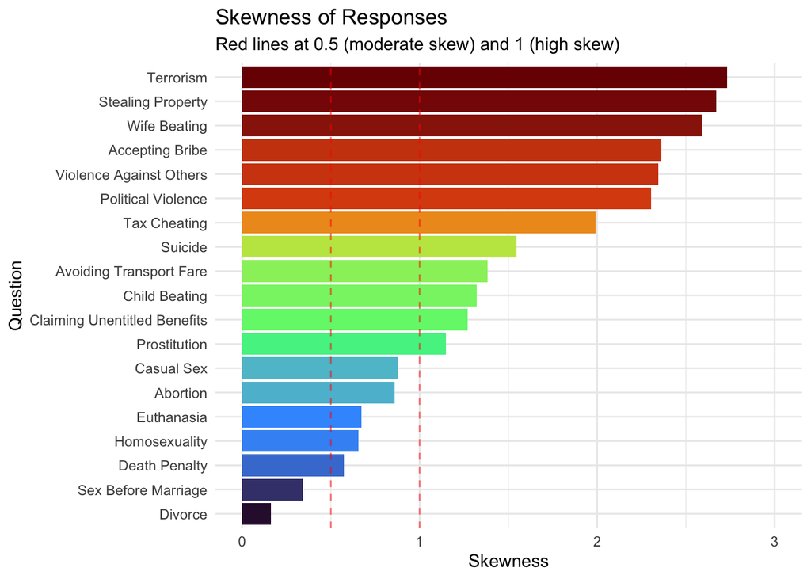

This informs us that the mean is an ill-suited measure to the data.

We can an intuitive grouping of actions – some questions have less consensus/are more controversial.

#### The Median: The Middle Value in a Sorted List (50% of data is below it, 50% is above)

- The median is less sensitive to extreme values (outliers) than the mean.
- A lower median would mean that most people reject the action as unjustifiable.
- A higher median suggests widespread justification of the action.
- Together, if the mean and median differ significantly, we can conclude that the data is skewed.

```r
# calculate the median for each question
median_data <- wvs_qs %>%
  select(Q177:Q195) %>%
  summarise(across(everything(), median, na.rm = TRUE))
```

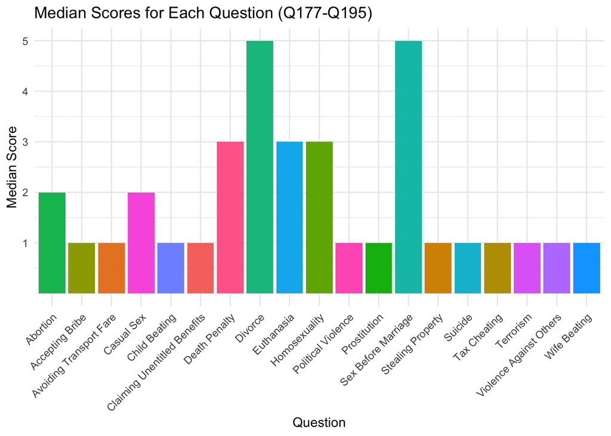

**Why Might We Hesitate to Use the Median?**

- The median only tells us the middle value, not how spread out the data is.
- If there are two peaks in the distribution, the median can be misleading as it may fall in the middle without reflecting extreme opinions.

#### The Median + Upper (Q3) and Lower Quartiles (Q1), and the Interquartile Range (IQR)

Investigating the Upper and Lower Quartiles may lead us to more insights into the data.

- These values can detect polarisation
  - A large IQR with a median near the middle suggests polarised views
  - If Q1 and Q3 are close to the median, most people generally agree on a response.
- These values can enhance the analysis by showing variability and distribution shape
  - If the IQR is small, responses are consistent around the median.
  - If the IQR is large, opinions are more spread out, suggesting greater disagreement.
- Q1 and Q3 can detect skewness, and the direction of skewness
  - If Q3 is further from the median than Q1, responses are positively skewed – respondents have provided more high scores
  - If Q1 is much further from the median than Q3, responses are negatively skewed – respondents have provided more low scores

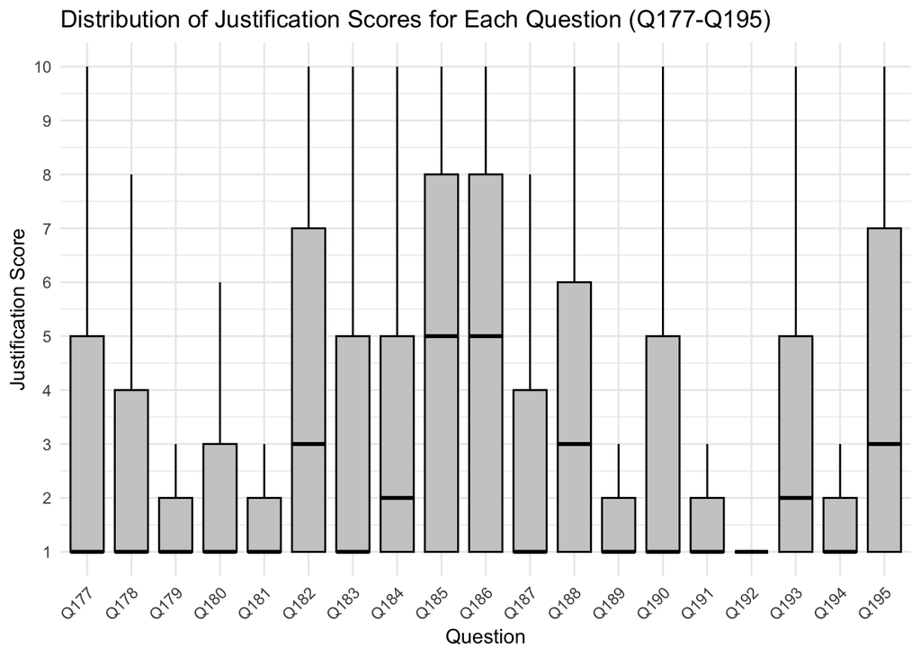

**Why Might We Hesitate to Use These Values?**

- Use of these values can miss important nuances, like the shape or presence of multiple peaks.
- They don’t reflect how dispersed values are in the IQR, ignoring patterns in the distribution.

#### The Mode: The Most Frequently Occurring Response for a Given Action

- The mode identifies the dominant opinion
- If multiple values appear frequently, the action might be controversial
- If there is a distinct mode value, opinions on the action can be assumed to be homogeneous

**The Mode per Question**

```r
# function to compute the mode (from ChatGPT)
compute_mode <- function(x) {
  uniq_x <- unique(na.omit(x))  # remove NAs and get unique values
  uniq_x[which.max(tabulate(match(x, uniq_x)))]  # return the most frequent value
}

mode_data <- wvs_qs %>%
  summarise(across(Q177:Q195, compute_mode, .names = "mode_{.col}")) %>%
  pivot_longer(cols = everything(), names_to = "question", values_to = "mode_value") %>%
  mutate(question = stringr::str_remove(question, "mode_")) %>%
  mutate(question_label = dplyr::recode(question, !!!question_labels))
```

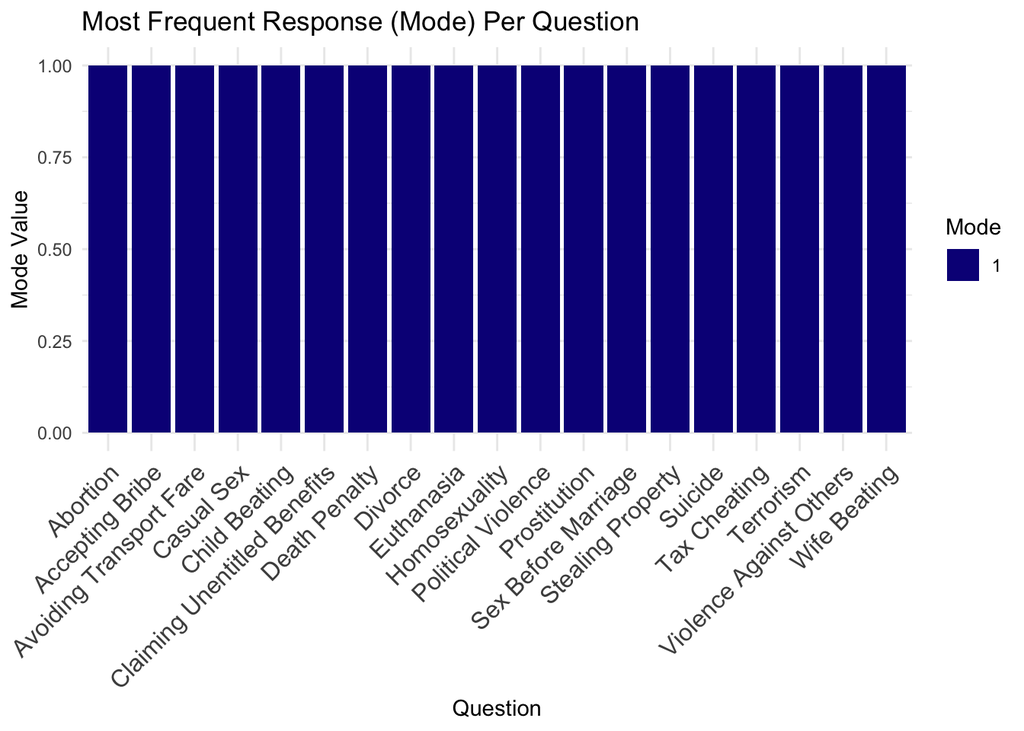

**Why Might We Hesitate to Use the Mode?**

- The mode ignores the frequency of other responses – only tells us the most common value
- If two or more values occur frequently (multimodal), the mode can be ambiguous.

The mode is homogeneous across all questions and countries, so does not tell us anything meaningful about the data or differences in opinion across questions and countries. We gain a heightened understanding of the data through looking at the second and third most frequent values.

**Second and Third Mode Functions**

```r
# function to compute the second highest response variable
compute_second_mode <- function(x) {
  x <- na.omit(x)  # remove NAs
  if (length(x) < 2) return(NA)  # return NA if there aren't enough unique values

  freq_table <- table(x)  # count occurrences
  sorted_values <- names(sort(freq_table, decreasing = TRUE))  # sort by frequency

  if (length(sorted_values) < 2) {
    return(NA)  # return NA if there's only one unique value
  } else {
    return(as.numeric(sorted_values[2]))  # return second most frequent value
  }
}

# function to compute the third highest response variable
compute_third_mode <- function(x) {
  x <- na.omit(x)  # remove NAs
  if (length(x) < 3) return(NA)  # return NA if there aren't enough unique values

  freq_table <- table(x)  # count occurrences
  sorted_values <- names(sort(freq_table, decreasing = TRUE))  # sort by frequency

  if (length(sorted_values) < 3) {
    return(NA)  # return NA if there are fewer than three unique values
  } else {
    return(as.numeric(sorted_values[3]))  # return third most frequent value
  }
}
```

**Mode, Second Mode, and Third Mode Values**

```r
wvs_mode <- wvs_long %>%
  group_by(question) %>%
  summarise(
    mode = compute_mode(response),
    second_mode = compute_second_mode(response),
    third_mode = compute_third_mode(response)
  )
```

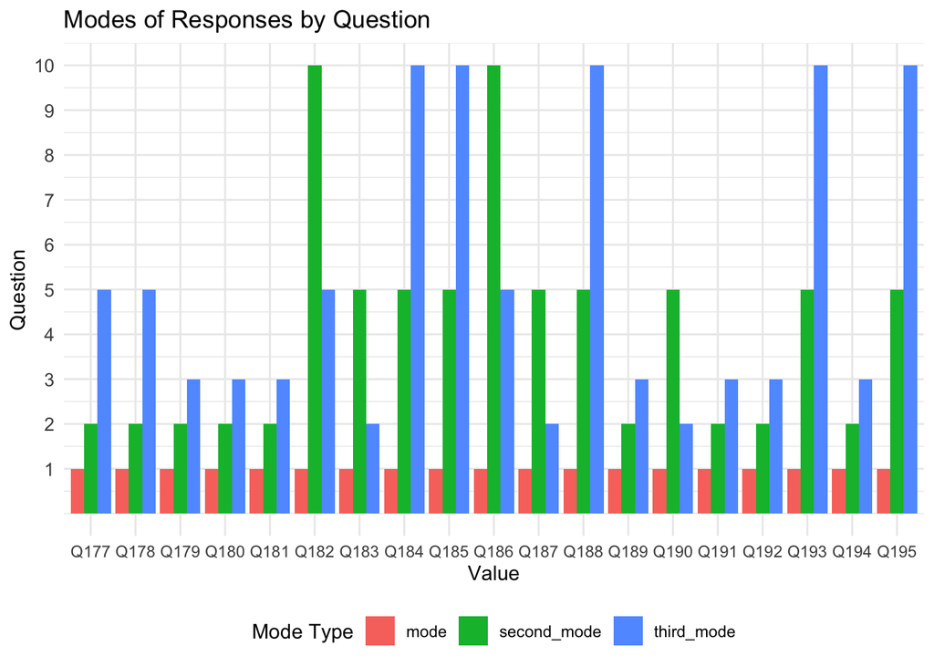

This graph provides an initial view of the most common responses, but to fully understand respondents’ attitudes, we need to analyse the entire distribution of responses through relative frequency graphs.

**Relative Frequency Graphs per Question**

```r
relative_freq_data <- wvs_long %>%
  filter(response %in% 1:10) %>%  # ensure responses are within 1-10
  group_by(question, response) %>%
  summarise(count = n(), .groups = "drop") %>%
  group_by(question) %>%
  mutate(percentage = (count / sum(count)) * 100)  # compute percentage
```

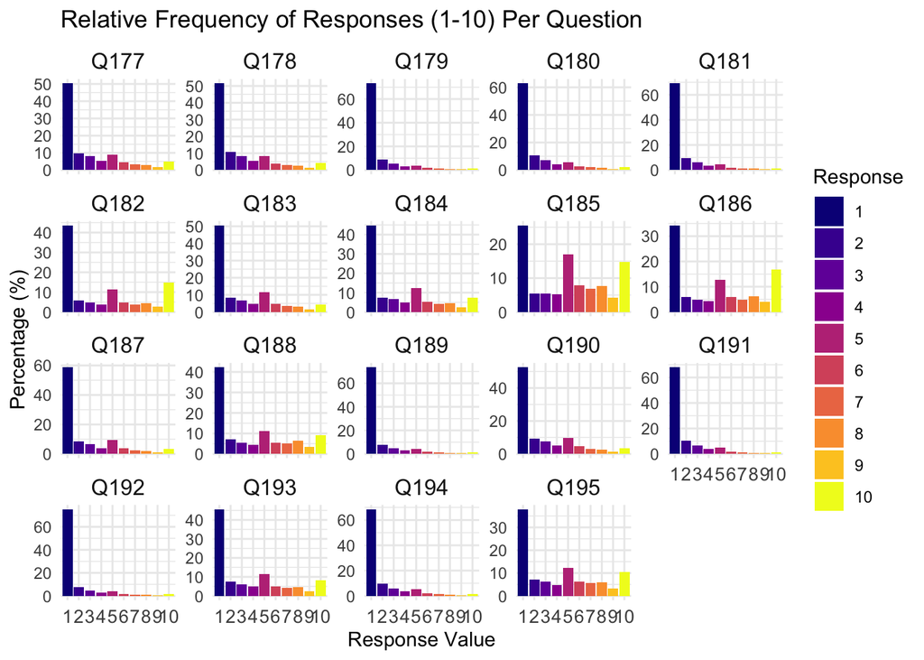

Using the mode alone classifies each action as “Never Justifiable”, but the relative frequency graphs reveal important differences in variation and distribution that the mode fails to capture. For instance, while the mode for Q185: Divorce is 1, only roughly 25% of respondents selected this option, indicating a more diverse range of opinions than the mode suggests. This limitation led us to explore distribution parameters for deeper analysis, enabling pairwise comparisons and comparative judgments as an alternative approach to answering our primary research question: “What Actions Can Be Justified?”

#### The Variance: How Much Individual Responses Deviate From the Mean from 0 (agreement)

- A low variance means most people gave similar responses, indicating consensus.
- A high variance suggests disagreement – some justify the action while others reject it.
  - This may signal polarisation within a society regarding a particular action.
- It is harder to interpret than standard deviation (not in the unit of the original scores)
- It is influenced by extreme values as outliers can make variance large
- It is not useful alone as variance needs context – knowing how responses are spread is more meaningful than just knowing that they’re spread out.

We will examine the possibility of using the standard deviation as a transformation of the variance.

#### The Standard Distribution: A Measure of Dispersion in the Same Unit as the Original Scores (1-10)

- This measure is more interpretable than the variance
- A small standard deviation means responses are close to the mean – agreement.
- A large standard deviation means responses are widely spread out – mixed opinions.  
  e.g. if a country’s standard deviation for “Q184: Abortion” is low, most people either strongly justify or strongly reject bribery, and if it is high, opinions vary greatly within the population.

```r
# calculate the standard deviation for each question
sd_data <- wvs_qs %>%
  select(Q177:Q195) %>%
  summarise(across(everything(), sd, na.rm = TRUE))
```

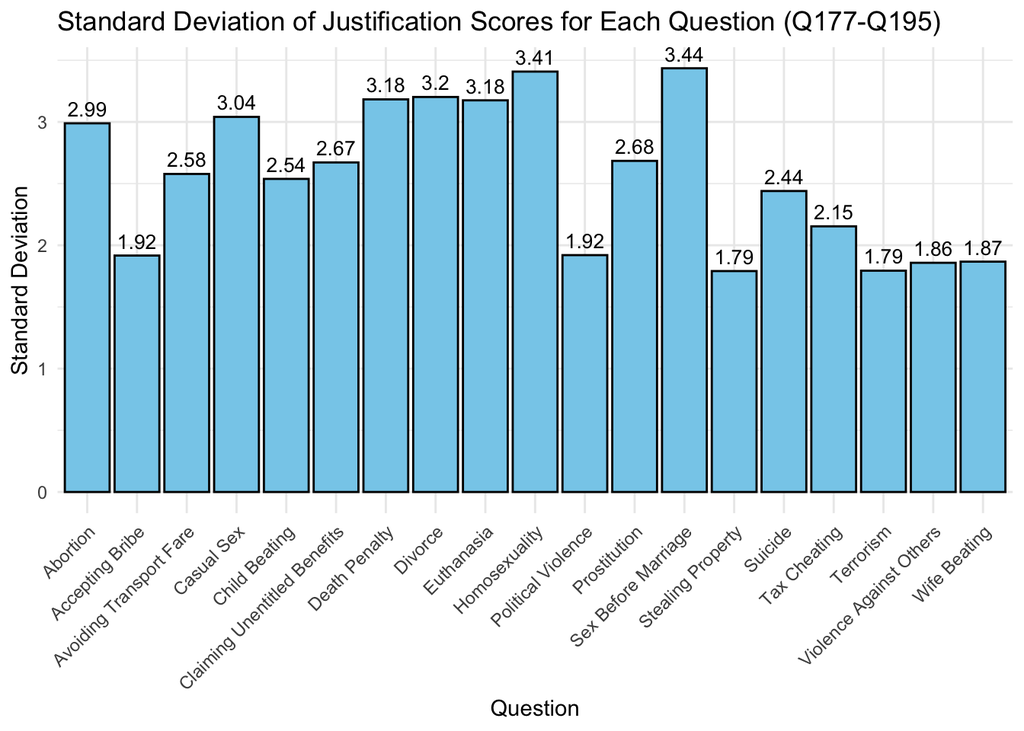

- This value assumes normality, and so is most meaningful when data follows a normal distribution, but moral attitudes among a population often don’t.
- It does not show the direction of skewness towards justification or unjustification, just spread
- It is sensitive to outliers; extreme responses can inflate the standard deviation

#### The Geometric Mean

In face of the drawbacks of using the arithmetic mean, we explored the method of taking the mean of the log distribution then back-transforming by the exponential (`~exp()`) to give us the geometric mean of the original distribution. The geometric mean gives more weight to the common lower values. Since the arithmetic mean is pulled up by high values, this should provide a more representative average value.

- It is less sensitive to extreme values than the arithmetic mean because it multiplies values instead of summing them - this is particularly useful if some respondents rated actions as “Always Justifiable” (10) or “Never Justifiable” (1) in an extreme manner, distorting the arithmetic mean.
- We use the log transformation, as it rightly suggests the data is right-skewed
- The geometric mean naturally reduces skewness and gives a more balanced central tendency.

```r
geometric_means <- wvs_qs %>%
  summarise(across(Q177:Q195, ~exp(mean(log(.), na.rm = TRUE)))) %>%
  pivot_longer(cols = Q177:Q195,
              names_to = "question",
              values_to = "geometric_mean")
```

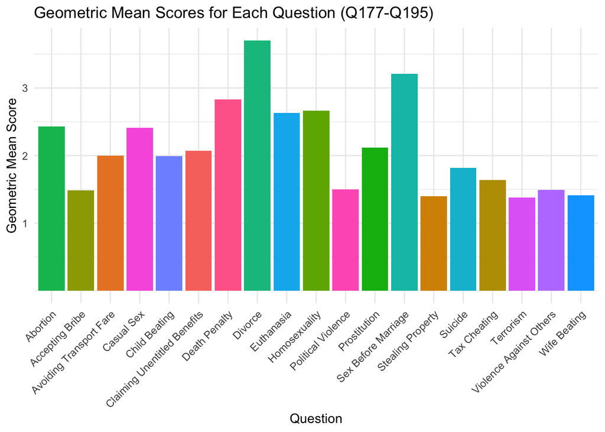

In comparison to the Arithmetic Mean (the graph is shown under The Arithmetic Mean: The Central Tendency or Average), we see that respondents’ action classifications generally lean towards the lower end of the scale, classifying most actions as unjustifiable. However, Divorce and Sex Before Marriage show higher values, suggesting greater acceptance or more variation in justification across respondents.

```r
mean_comparison <- geometric_means %>%
  left_join(mean_long, by = "question") %>%
  mutate(
    mean_difference = mean - geometric_mean,
    mean_ratio = mean / geometric_mean
  )
```

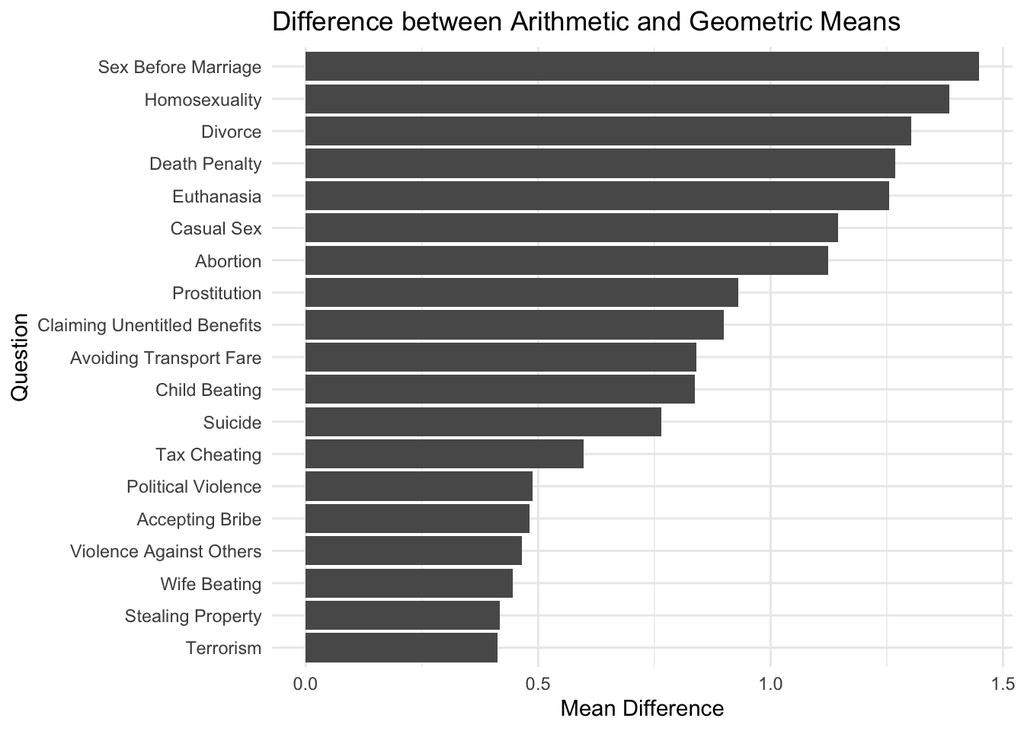

There is a large difference between the arithmetic and geometric means, as seen in actions like Sex Before Marriage, Homosexuality, and Divorce. This suggests there are outliers or a skewed distributions. The arithmetic mean is disproportionately affected by these extreme values, making it less reflective of the typical respondent’s view, whereas the geometric mean provides a more balanced and robust measure of central tendency. For questions with lower mean differences (e.g. Terrorism and Stealing Property), the data appears to be more uniform, and while the arithmetic mean may not be as skewed, the geometric mean still provides a more consistent measure of central tendency that is less influenced by any remaining small outliers or variations. It mitigates the influence of extreme responses and better captures the central position of the distribution, particularly when the data is skewed.

```r
# combine the datasets and add normalise mean difference
combined_analysis <- mean_comparison %>%
  left_join(skew_df, by = "question") %>%
  mutate(
    # normalize mean difference to 0-1 scale
    mean_diff_normalized = (mean_difference - min(mean_difference)) /
                          (max(mean_difference) - min(mean_difference))
  )

head(combined_analysis) %>% kable()
```

| question | geometric_mean | mean | mean_difference | mean_ratio | skewness | mean_diff_normalized |
| --- | --- | --- | --- | --- | --- | --- |
| Q177 | 2.074260 | 2.973475 | 0.8992153 | 1.433512 | 1.271190 | 0.4696382 |
| Q178 | 2.000658 | 2.841761 | 0.8411027 | 1.420413 | 1.382910 | 0.4135535 |
| Q179 | 1.401415 | 1.818169 | 0.4167548 | 1.297381 | 2.672285 | 0.0040138 |
| Q180 | 1.635634 | 2.233539 | 0.5979055 | 1.365550 | 1.991116 | 0.1788430 |
| Q181 | 1.485271 | 1.966051 | 0.4807802 | 1.323699 | 2.363168 | 0.0658049 |
| Q182 | 2.666869 | 4.051870 | 1.3850012 | 1.519336 | 0.654440 | 0.9384720 |

**Relationship between Skewness and Normalized Mean Difference**

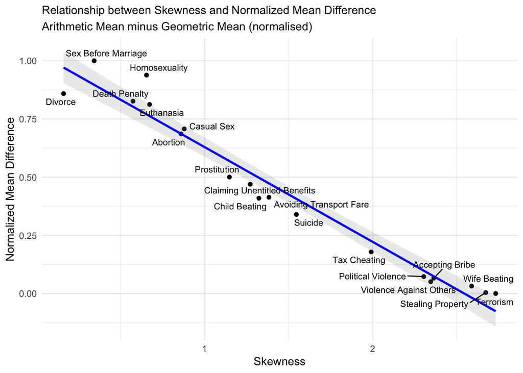

The relationship between normalized mean difference (NMD) and skewness illustrates how the geometric mean offers a direct solution to the challenges posed by skewed distributions. As the geometric mean is less affected by extreme values, it provides a more balanced central tendency measure compared to the arithmetic mean. The observed negative relationship between NMD and skewness can be attributed to the 1-10 scale of the questions, where extreme values contribute to skewness, and the geometric mean mitigates the impact of these extremes, providing a more reliable comparison.

**Combining All Descriptive Statistics**

```r
# getting second and third mode data to easily merge
second_mode_data <- wvs_qs %>%
  summarise(across(Q177:Q195, compute_second_mode, .names = "mode_{.col}")) %>%
  pivot_longer(cols = everything(), names_to = "question", values_to = "second_mode_value") %>%
  mutate(question = stringr::str_remove(question, "mode_")) %>%  # Clean question names
  mutate(question_label = dplyr::recode(question, !!!question_labels))  # Map to labels

third_mode_data <- wvs_qs %>%
  summarise(across(Q177:Q195, compute_third_mode, .names = "mode_{.col}")) %>%
  pivot_longer(cols = everything(), names_to = "question", values_to = "third_mode_value") %>%
  mutate(question = stringr::str_remove(question, "mode_")) %>%  # clean question names
  mutate(question_label = dplyr::recode(question, !!!question_labels))  # map to labels

# merge statistics for all questions
descriptive_statistics <- mean_long %>%
  left_join(geometric_means, by = "question") %>%
  left_join(median_long, by = "question") %>%
  left_join(mode_data, by = "question") %>%
  left_join(second_mode_data, by = "question") %>%
  left_join(third_mode_data, by = "question") %>%
  left_join(sd_long, by = "question") %>%
  select(-question_label.x, -question_label.y, -question_label)

# view the resulting dataframe
head(descriptive_statistics) %>% kable()
```

| question | mean | geometric_mean | median | mode_value | second_mode_value | third_mode_value | sd |
| --- | --- | --- | --- | --- | --- | --- | --- |
| Q177 | 2.973475 | 2.074260 | 1 | 1 | 2 | 5 | 2.671583 |
| Q178 | 2.841761 | 2.000658 | 1 | 1 | 2 | 5 | 2.578371 |
| Q179 | 1.818169 | 1.401415 | 1 | 1 | 2 | 3 | 1.791023 |
| Q180 | 2.233539 | 1.635634 | 1 | 1 | 2 | 3 | 2.153673 |
| Q181 | 1.966051 | 1.485271 | 1 | 1 | 2 | 3 | 1.916805 |
| Q182 | 4.051870 | 2.666869 | 3 | 1 | 10 | 5 | 3.408153 |

## 1.4 Which Actions Are Justified?

**Q177: Claiming Government Benefits to Which You Are Not Entitled**

| mean | geometric_mean | median | mode_value | second_mode_value | third_mode_value | sd |
| --- | --- | --- | --- | --- | --- | --- |
| 2.973475 | 2.07426 | 1 | 1 | 2 | 5 | 2.671583 |

For Q177, the mean response of 2.97 suggests that most respondents reject the action. The median score of 1 confirms that over half of the respondents place it at the lowest end of the scale. The mode of 1, with secondary and tertiary modes at 2 and 5 respectively, further indicate that the most common stance among respondents is disapproval, though some take a more neutral position. The geometric mean of 2.07, lower than the arithmetic mean, highlights the skewed nature of the responses, reinforcing the general tendency toward unjustifiability. Furthermore, the standard deviation suggests moderate variation, indicating that most respondents reject the action, but a subset expresses more leniency or neutrality. This is consistent in the literature as researchers found a similar mean (2.68), and additionally that income and being male is positively correlated with this action as opposed to age, education, and married status, all of which relate negatively (Navot, Reingewertz, and Cohen 2016). Overall, these statistics place this action firmly within the lower half of the justification scale, with widespread disapproval with some variation in attitudes, as reflected in the relative frequency graph below.

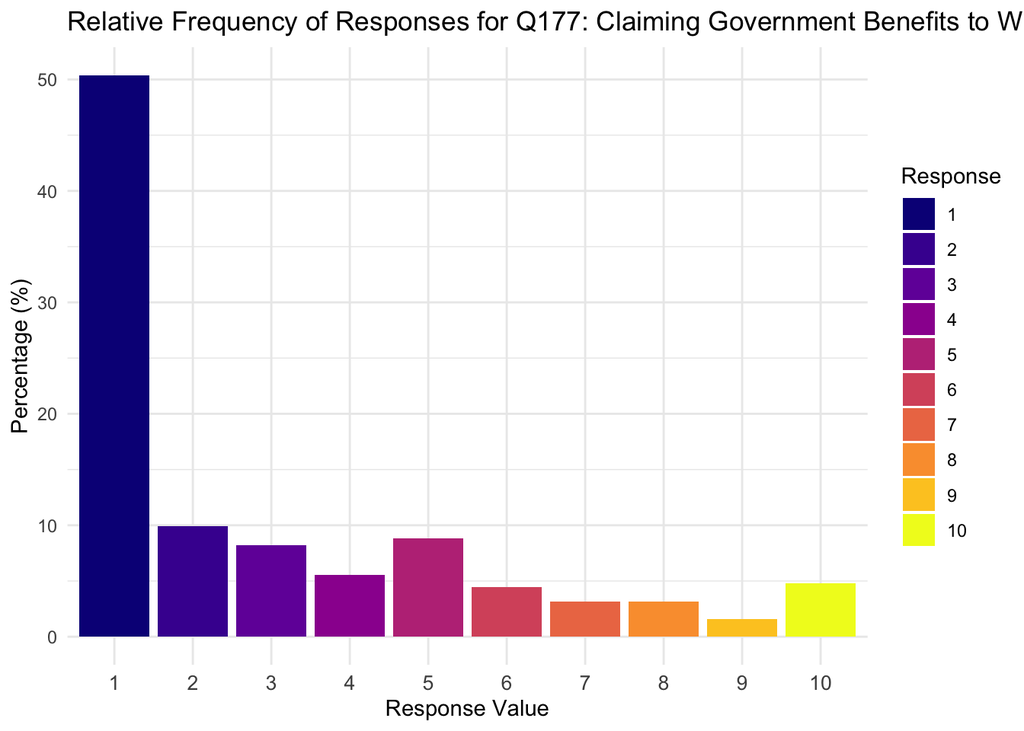

**Q178: Avoiding a Fare on Public Transport**

| mean | geometric_mean | median | mode_value | second_mode_value | third_mode_value | sd |
| --- | --- | --- | --- | --- | --- | --- |
| 2.841761 | 2.000658 | 1 | 1 | 2 | 5 | 2.578371 |

For Q178, “Avoiding a Fare on Public Transport”, the mean response of 2.84 suggests that the action is mostly rejected by respondents, a conclusion reinforced by the median of 1, indicating that over half of the responses fall at the lowest point on the scale. The mode of 1, (and secondary and tertiary modes at 2 and 5), further supports the dominant stance of disapproval, though a subset of respondents exhibits neutral or slightly more lenient views. The geometric mean of 2, notably lower than the arithmetic mean, highlights skewness in the distribution, emphasising that the majority lean toward unjustifiability. The standard deviation suggests moderate variation, indicating some divergence in opinion. Overall, while this action is largely deemed unjustifiable, the presence of secondary and tertiary modes, as well as the variation in responses, suggests that attitudes are not entirely uniform, as further illustrated in the relative frequency graph below.

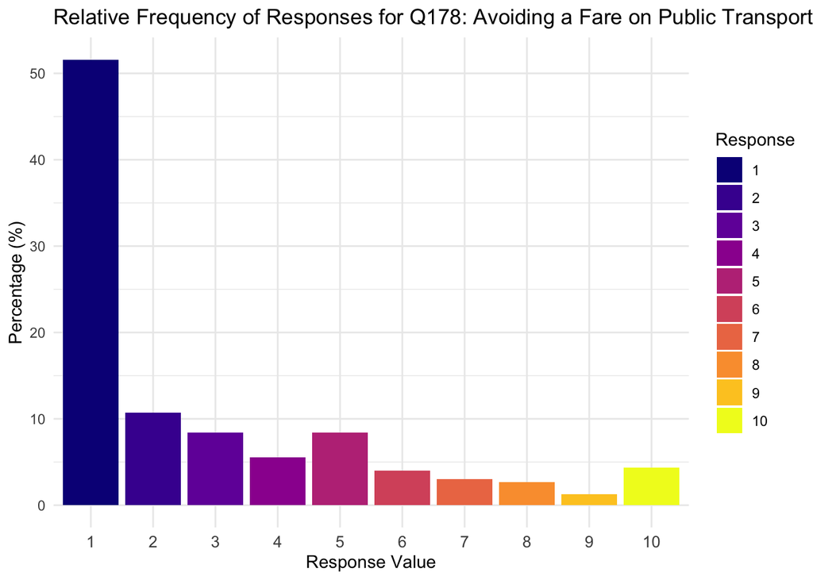

**Q179: Stealing Property**

| mean | geometric_mean | median | mode_value | second_mode_value | third_mode_value | sd |
| --- | --- | --- | --- | --- | --- | --- |
| 1.81817 | 1.401415 | 1 | 1 | 2 | 3 | 1.791023 |

For Q179, Stealing Property, the mean of 1.82 and median of 1 indicate overwhelming rejection, with the mode of 1 accounting for over 70% of responses (see the relative frequency graph displayed below), signaling a strong consensus. The geometric mean of 1.40, lower than the arithmetic mean, highlights skewness toward disapproval. Secondary and tertiary modes at 2 and 3 suggest minimal leniency, while the standard deviation of 1.79 reflects low variation. Overall, this action is widely deemed unjustifiable. This conclusion is supported by previous research, in which - out of questions 177, 178, 179, 180, and 181 - stealing property had the lowest mean and was thus viewed as the least justifiable among these actions [Navot, Reingewertz, and Cohen (2016). Further, this un-justifiability extends to stealing in the form of illegal downloading, in which South Asians and North Americans scored the behaviour higher in terms of criminality (Babb 2015).

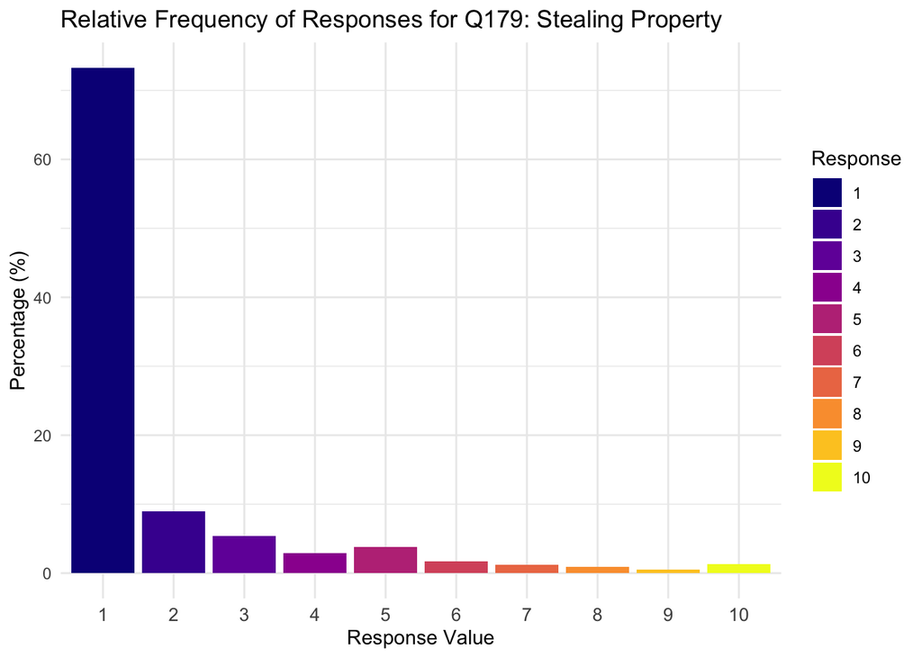

**Q180: Cheating on Taxes If You Have a Chance**

| mean | geometric_mean | median | mode_value | second_mode_value | third_mode_value | sd |
| --- | --- | --- | --- | --- | --- | --- |
| 2.233539 | 1.635634 | 1 | 1 | 2 | 3 | 2.153673 |

For Q180, the mean of 2.23 and median of 1 indicate strong rejection, alongside the mode of 1. The geometric mean of 1.64, lower than the arithmetic mean, shows skewness toward unjustifiability. Secondary and tertiary modes at 2 and 3 suggest some minor variation in responses, while the standard deviation of 2.15 reflects moderate dispersion. Overall, this action is largely deemed unjustifiable, though some respondents show slight divergence in opinion. This divergence may be due to the gender of the respondent as women are more disapproving of tax evasion (Torgler and Valev 2010), and tax cooperation or “tax morale” has increased in Western Europe (Torgler and Schneider 2005).

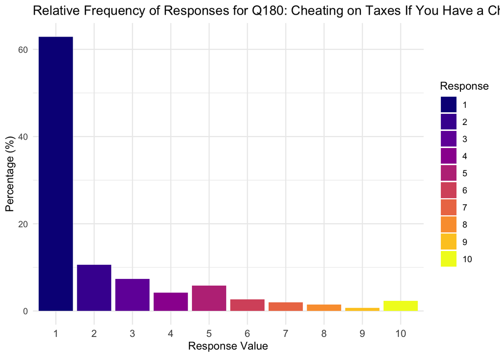

**Q181: Someone Accepting a Bribe in the Course of Their Duties**

| mean | geometric_mean | median | mode_value | second_mode_value | third_mode_value | sd |
| --- | --- | --- | --- | --- | --- | --- |
| 1.966051 | 1.485271 | 1 | 1 | 2 | 3 | 1.916805 |

For Q181, the mean of 1.97 and median of 1 indicate strong disapproval, with the mode of 1 as the most common response. The geometric mean of 1.49, lower than the arithmetic mean, highlights skewness toward unjustifiability. Secondary and tertiary modes at 2 and 3 suggest minor variation, while the standard deviation of 1.92 reflects moderate spread. Overall, this action is widely considered unjustifiable, with limited divergence in responses. Despite the limited divergence observed, researchers have noted gender (Torgler and Valev 2010) and religious differences in the acceptance of bribes, for example the highest justifiability scores were from Muslims, followed by Buddhists, Hindus, Jews, Christians and finally Baha’is (McGee, Benk, and Yüzbaşı 2015).

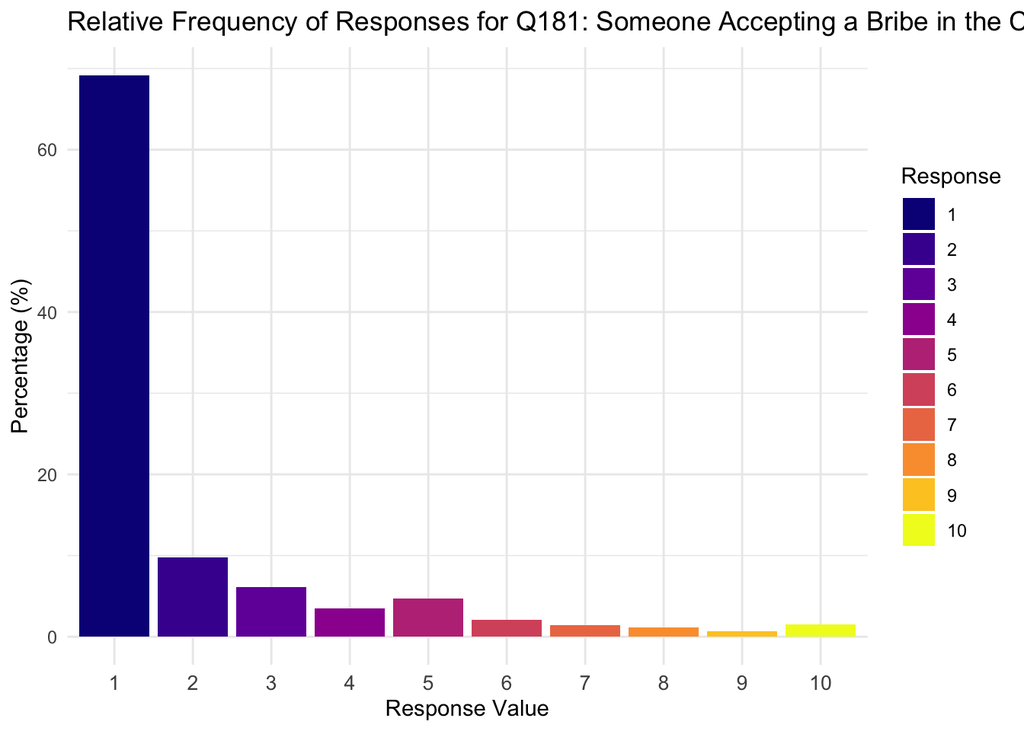

**Q182: Homosexuality**

| mean | geometric_mean | median | mode_value | second_mode_value | third_mode_value | sd |
| --- | --- | --- | --- | --- | --- | --- |
| 4.05187 | 2.666869 | 3 | 1 | 10 | 5 | 3.408153 |

For Q182, the mean of 4.05 suggests a mixed stance, though the median (3) indicates that most responses still lean toward unjustifiability. The mode of 1 remains to be the most common response, but the secondary mode of 10 suggests polarisation, with some respondents deeming the action “Always Justifiable”. The geometric mean of 2.67, significantly lower than the arithmetic mean, highlights skewness toward lower justifiability scores, and a standard deviation of 3.41 reflects high variation, indicating divergent views rather than a clear consensus. Overall, opinions on this action appear divided, as both strong rejection and full justification present. The discrepancies observed in attitudes towards homosexuality are potentially caused by a multitude of socio-cultural factors. Some researchers put negative attitudes down to authoritarianism, inflexible religious beliefs/behaviours, importance of traditional sex roles, less contact with homosexuals (Furnham and Saito 2009), religiosity, and belonging to “the former Soviet and Eastern Bloc, the Muslim World, and sub-Saharan Africa” (Roberts 2019).

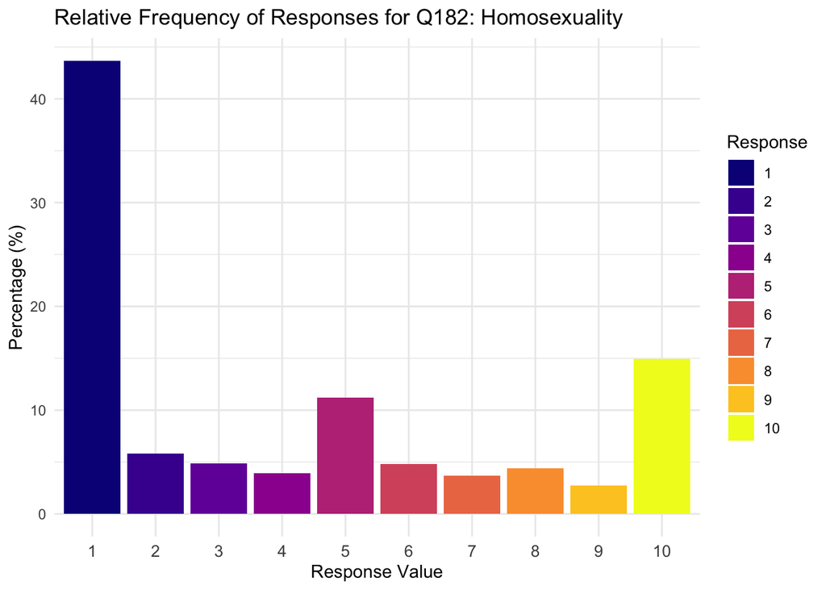

**Q183: Prostitution**

| mean | geometric_mean | median | mode_value | second_mode_value | third_mode_value | sd |
| --- | --- | --- | --- | --- | --- | --- |
| 3.049633 | 2.11845 | 1 | 1 | 5 | 2 | 2.684308 |

For Q183, the mean of 3.05 suggests respondents generally lean toward unjustifiability, reinforced by the median of 1 and a mode of 1, indicating that the most common response is strong disapproval. However, the secondary mode of 5 suggests some neutrality, however the tertiary mode of 2 further supports a tendency toward rejection. The geometric mean of 2.12, notably lower than the arithmetic mean, highlights skewness toward lower justifiability scores. A standard deviation of 2.68 reflects moderate variation, suggesting that while most respondents consider prostitution unjustifiable, a subset holds more neutral or lenient views. Overall, this action is predominantly seen as unjustifiable, but responses indicate some divergence in opinion. Divergence may result from varying beliefs in marriage (Chon 2015), “political conservatism, authoritarianism and religious fundamentalism”, all of which predict attitudes to prostitution, as well as religiosity, religious denominations and the “survivalist orientation” of one’s country (Stack, Adamczyk, and Cao 2010).

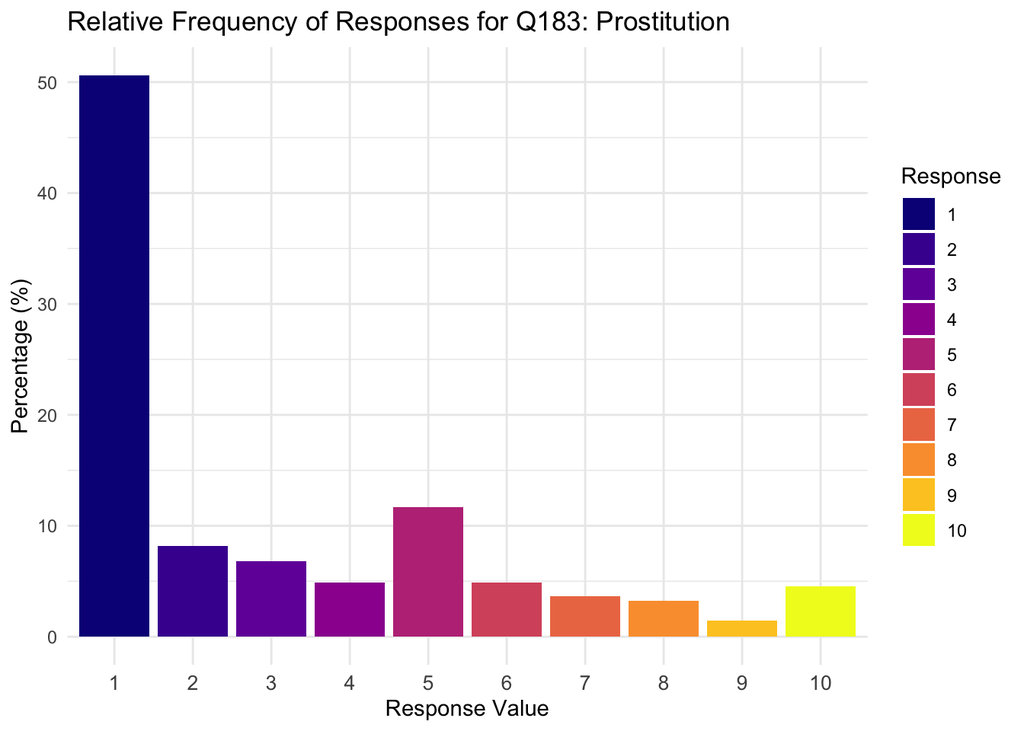

**Q184: Abortion**

| mean | geometric_mean | median | mode_value | second_mode_value | third_mode_value | sd |
| --- | --- | --- | --- | --- | --- | --- |
| 3.554184 | 2.430881 | 2 | 1 | 5 | 10 | 2.988838 |

For Q184, the mean of 3.55 suggests a moderate rejection, though the median of 2 indicates most responses are closer to the lower end of the scale. The mode of 1 reflects strong disapproval is most common. However, the secondary and tertiary modes of 5 and 10 respectively indicate significant polarisation, with some respondents showing neutrality and others fully justifying the action. The geometric mean of 2.43, lower than the arithmetic mean, reflects skewness toward lower justification scores. The standard deviation of 2.99 shows high variation, suggesting that views on abortion are divided, with both strong disapproval and justification present in the responses. Overall, opinions on abortion are mixed, with a general tendency toward rejection but notable polarisation in attitudes. This polarisation is well-documented, researchers having noted on the “extreme positions” taken ranging from absolute bans to absolute rights (Tutić Grokša et al. 2025). Abortion is a controversial bioethical issue on which attitudes and even laws differ regionally and internationally. Positive abortion attitudes are more present in women, younger age groups, more educated, and less religious individuals (Loll and Hall 2019). At the cultural level, opposition to abortion is largely founded in religion, but is also related to countries with lower GDP (Tutić Grokša et al. 2025).

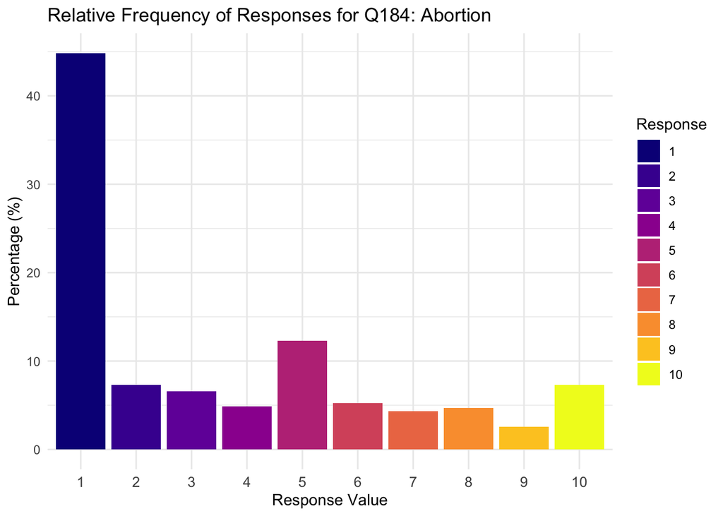

**Q185: Divorce**

| mean | geometric_mean | median | mode_value | second_mode_value | third_mode_value | sd |
| --- | --- | --- | --- | --- | --- | --- |
| 5.007262 | 3.704647 | 5 | 1 | 5 | 10 | 3.202261 |

For Q185, the mean of 5.01 and median of 5 indicate a neutral stance, but the mode of 1, representing 25% of responses, shows significant disapproval. The secondary mode of 5 suggests greater acceptance, while the tertiary mode of 10 reflects strong justification of divorce. The geometric mean of 3.70, lower than the arithmetic, highlights skewness toward lower justification scores. The high standard deviation of 3.20 suggests diverse opinions on divorce. It is more justifiable than any other action, though opinions remain polarised, with both strong disapproval and justification present, but investigating the relative frequency graph shows most responses, if not 1, “Never Justifiable”, tend to be a value of 5 or above, making it reasonable to conclude that Divorce is a widely justifiable action. Evaluations and rates of divorce are noted to be “systematically linked to cultural values”, specifically the individualism-collectivism dimension, national wealth, and family values (Toth and Kemmelmeier 2009), which explains the variation in justifiability scores.

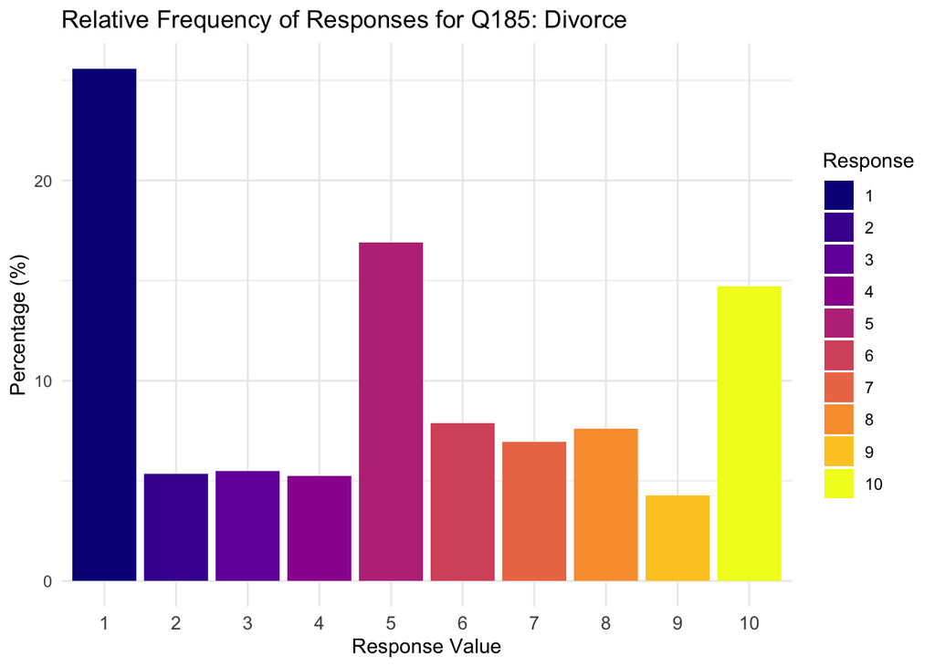

**Q186: Sex Before Marriage**

| mean | geometric_mean | median | mode_value | second_mode_value | third_mode_value | sd |
| --- | --- | --- | --- | --- | --- | --- |
| 4.655488 | 3.206734 | 5 | 1 | 10 | 5 | 3.435047 |

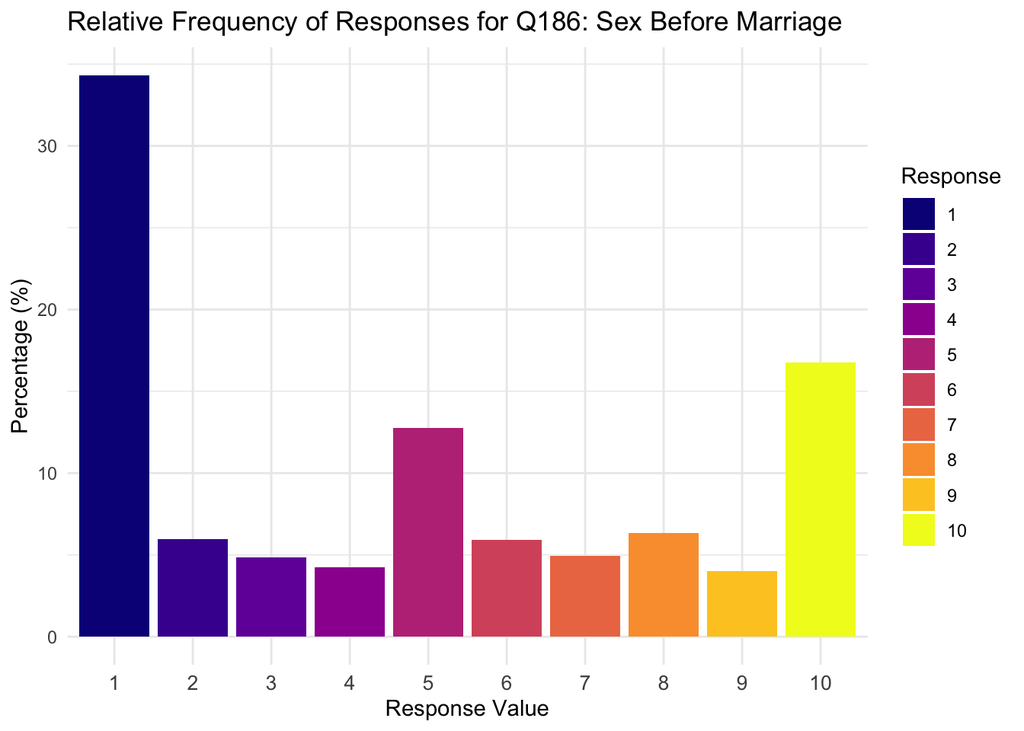

**Q187: Suicide**

| mean | geometric_mean | median | mode_value | second_mode_value | third_mode_value | sd |
| --- | --- | --- | --- | --- | --- | --- |
| 2.581409 | 1.8169 | 1 | 1 | 5 | 2 | 2.439957 |

For Q187, the mean of 2.58 and median of 1 suggest strong disapproval of the action, with the mode of 1 representing the most common response is that suicide is “Never Justifiable”, indicating a clear rejection of suicide. However, the secondary mode (5) shows some neutrality. The geometric mean of 1.82, significantly lower than the arithmetic mean, highlights skewness toward strong disapproval. The standard deviation of 2.44 suggests moderate variation, indicating some divergence in opinions. Overall, suicide is largely viewed as unjustifiable, though a minority holds more neutral or lenient views. Some researchers have posited differences in perspectives regarding suicide may lie along the individualism-collectivism dimension (Colucci and Lester 2012).

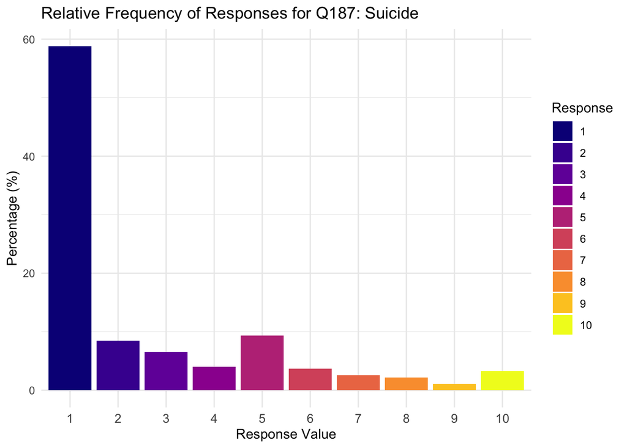

**Q188: Euthanasia**

| mean | geometric_mean | median | mode_value | second_mode_value | third_mode_value | sd |
| --- | --- | --- | --- | --- | --- | --- |
| 3.882075 | 2.627797 | 3 | 1 | 5 | 10 | 3.175178 |

Euthanasia For Q188, the mean of 3.88 and median of 3 suggest moderate rejection, though the mode of 1 indicates a significant portion (~40%) of respondents disapprove. The secondary mode of 5 and tertiary mode of 10 show polarisation, with some respondents taking a neutral stance or strongly justifying euthanasia. The standard deviation of 3.18 suggests high variation, indicating diverse opinions. In comparison to suicide (Q187), where the mean of 2.58 and median of 1 show strong disapproval, euthanasia shows more variation and polarisation. While both actions are viewed largely unjustifiable, euthanasia exhibits greater divergence in opinion, as seen in the higher mean, secondary mode of 5, and tertiary mode of 10, indicating a more divided view than the clear rejection of suicide. This is supported by the fact a previous analysis of the WVS suggested that “approximately half the population approved of euthanasia” (Karumathil and Tripathi 2022). The discrepancies in attitudes towards euthanasia can be traced back to both individual and cultural factors. Those who are older, live in rural regions, and of lower socioeconomic status generally possess more negative views regarding euthanasia (Tutić Grokša et al. 2025). Culturally, Christianity presents more “prohibitive” attitudes, and other religions also influence acceptability e.g., Hinduism and Islam (Karumathil and Tripathi 2022), as well as traditional family values (Lee et al. 1996).

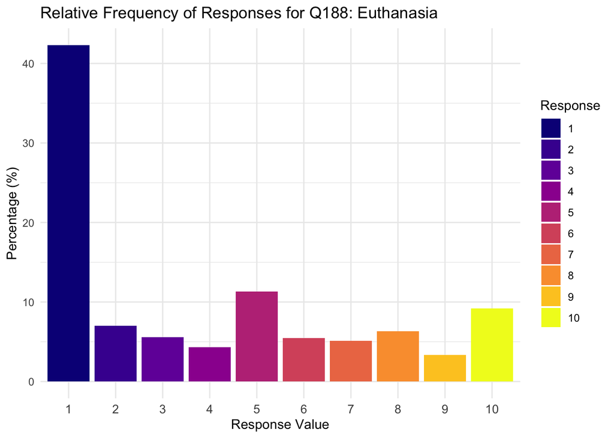

**Q189: For a Man to Beat His Wife**

| mean | geometric_mean | median | mode_value | second_mode_value | third_mode_value | sd |
| --- | --- | --- | --- | --- | --- | --- |
| 1.858026 | 1.412235 | 1 | 1 | 2 | 3 | 1.867325 |

For Q189, the mean of 1.86 and median of 1 indicate strong disapproval, with the mode of 1 representing the most common response, reflecting clear rejection of this action. The secondary mode of 2 and tertiary mode of 3 suggest minor variation, with some respondents holding more lenient views. The standard deviation of 1.87 suggests moderate variation, showing that while the majority reject the action, there is some divergence in opinions, but overall, a man beating his wife is widely viewed by respondents as unjustifiable, with strong rejection yet some variation. This variation is observed in research as despite staunch opposition, some countries - “Mali, Serbia, Montenegro, Zambia, Burkina Faso, India, the Philippines, Rwanda, Egypt, and Algeria” - somewhat accept intimate partner violence (Tausch 2019). Disrespect towards traditional family values explained the most variance of acceptability (Tausch 2019).

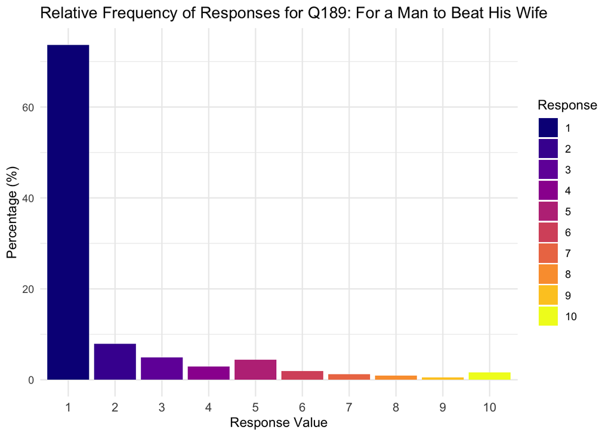

**Q190: Parents Beating Children**

| mean | geometric_mean | median | mode_value | second_mode_value | third_mode_value | sd |
| --- | --- | --- | --- | --- | --- | --- |
| 2.831576 | 1.994555 | 1 | 1 | 5 | 2 | 2.538224 |

For Q190, the mean of 2.83 and median of 1 suggest strong disapproval, with the mode of 1 representing the most common response. However, the secondary mode of 5 and tertiary mode of 2 indicate slight polarisation, with a subset of respondents holding neutral and more lenient views. The standard deviation of 2.54 indicates moderate variation, suggesting diverse opinions on the issue. Compared to the action of a man beating his wife (Q189), where the mean of 1.86 and mode of 1 suggest a stronger consensus against the action, parents beating children shows more variation. While both actions are widely rejected, polarisation occurs in the case of parents beating children, as is reflected in the secondary mode of 5 and a higher standard deviation. This indicates that while the majority of respondents reject the action, there is greater divergence in opinions about whether it can ever be justified, whereas wife beating is overwhelmingly condemned. The increased justifiability observed is likely due to the fact that corporal punishment of children is either rare or a “frequent child-training technique in many societies”, predicted by “dependence on agriculture”, and political/economic complexity (Ember and Ember 2005). The discrepancy observed between the justifiability of child and wife beating is that the former is associated with learning while the latter with punishment (Almosaed 2004).

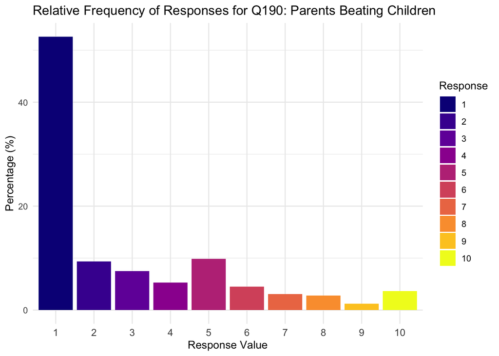

**Q191: Violence Against Other People**

| mean | geometric_mean | median | mode_value | second_mode_value | third_mode_value | sd |
| --- | --- | --- | --- | --- | --- | --- |
| 1.96055 | 1.495263 | 1 | 1 | 2 | 3 | 1.858066 |

For Q191, the mean of 1.96 and median of 1 suggest strong disapproval, with the mode of 1 as the most common response. The secondary mode of 2 and tertiary mode of 3 indicate some leniency, but the majority still firmly reject the action. The standard deviation of 1.86 reflects low variation, but suggests slight divergence in opinions. Overall, this action is largely deemed unjustifiable. While violence against other people shares the strong rejection seen in wife beating (Q189), it shows slightly less variation than both wife beating and child beating (Q190), as indicated by its lower standard deviation. This suggests that while the action is widely condemned, there is less divergence in opinions on violence against others compared to the near-universal rejection of wife beating, and more diverse attitudes towards child beating, a fascinating insight from the data. This is despite the fact violence occurs within “every socio‐economic group, ideology, class, race and ethnic grouping” (Almosaed 2004).

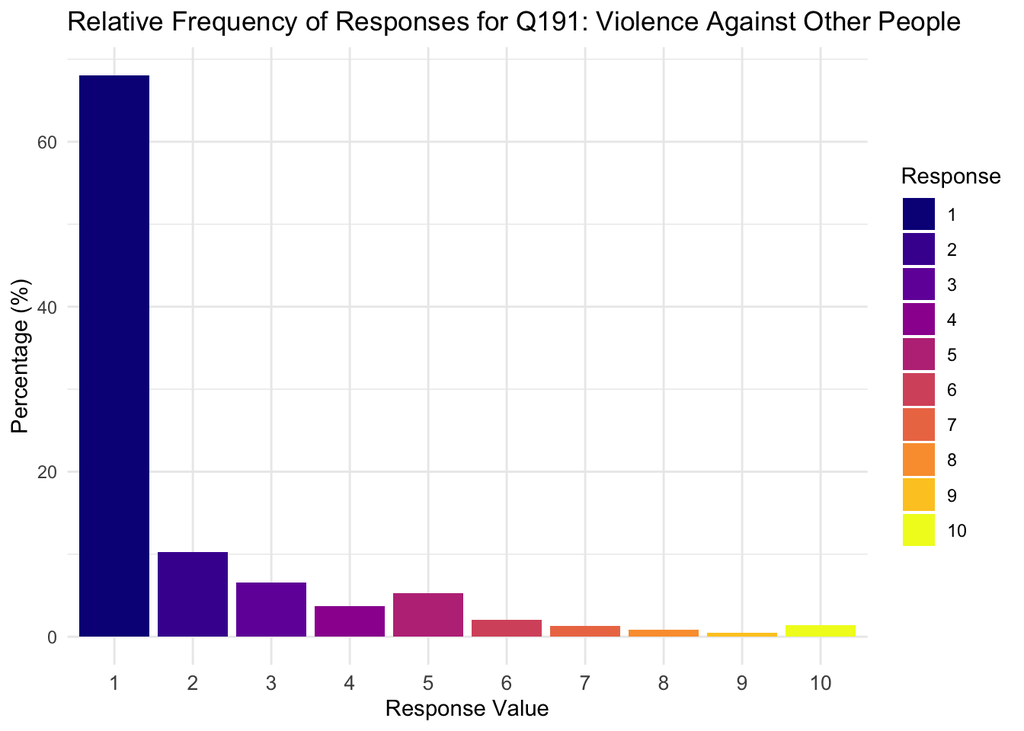

**Q192: Terrorism as a Political, Ideological or Religious Means**

| mean | geometric_mean | median | mode_value | second_mode_value | third_mode_value | sd |
| --- | --- | --- | --- | --- | --- | --- |
| 1.789475 | 1.37688 | 1 | 1 | 2 | 3 | 1.794037 |

For Q192, the mean of 1.79 and median of 1 suggest strong disapproval, with the mode of 1 supporting this. The secondary mode of 2 and tertiary mode of 3 indicate some leniency, but the majority still firmly reject the action. The standard deviation of 1.79 shows slight variation, suggesting some divergence in opinions, though terrorism is largely viewed as unjustifiable. The observed variance may result from the fact that terrorism in itself is difficult to define (Martínez, Sánchez, and Galindo 2022), and relative to perspectives (Lee et al. 2004). Individual factors that may result in justification include youth, naivety, poor life satisfaction and health, and religion (Martínez, Sánchez, and Galindo 2022). The rejection of terrorism is consistently expressed, such as by the UN which states such acts have “no justification in our societies” (Martínez, Sánchez, and Galindo 2022), which likely affects scores.

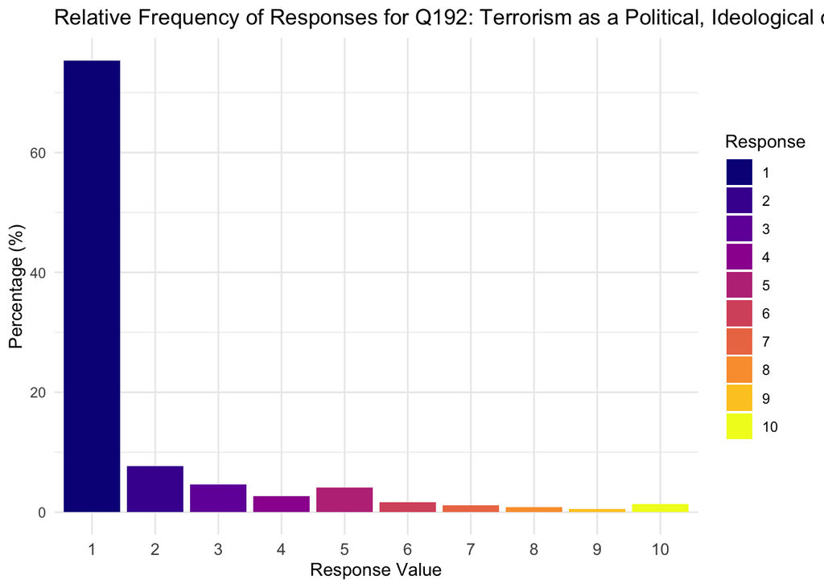

**Q193: Having Casual Sex**

| mean | geometric_mean | median | mode_value | second_mode_value | third_mode_value | sd |
| --- | --- | --- | --- | --- | --- | --- |
| 3.555538 | 2.410104 | 2 | 1 | 5 | 10 | 3.040943 |

[figure not shown]

**Q194: Political Violence**

| mean | geometric_mean | median | mode_value | second_mode_value | third_mode_value | sd |
| --- | --- | --- | --- | --- | --- | --- |
| 1.987385 | 1.499409 | 1 | 1 | 2 | 3 | 1.920265 |

For Q194, “Political Violence”, the mean of 1.99 and median of 1 suggest strong disapproval, alongside the mode of 1. The secondary mode of 2 and tertiary mode of 3 indicate slight leniency, but it is still majorly rejected. The standard deviation of 1.92 suggests slight variation, indicating some divergence in opinions, though political violence is largely viewed as unjustifiable. In comparison, to Q192: “Terrorism as a Political, Ideological or Religious Means”, there is a similar pattern, with a low mean of less than 2. The secondary mode of 2 and tertiary mode of 3 also suggest similarly suggest slight leniency, and the standard deviation of 1.79 indicates slight variation. While both actions are strongly disapproved, terrorism tends to show slightly stronger disapproval overall, compared to political violence, which displays a bit more variation in attitudes.

[figure not shown]

**Q195: Death Penalty**

| mean | geometric_mean | median | mode_value | second_mode_value | third_mode_value | sd |
| --- | --- | --- | --- | --- | --- | --- |
| 4.098131 | 2.829311 | 3 | 1 | 5 | 10 | 3.182879 |

For Q195, the mean of 4.10 and median of 3 suggest slight rejection, with the mode of 1, as is the same across all actions, indicating strong disapproval. The secondary mode of 5 and tertiary mode of 10 reveal polarisation, with some respondents being more neutral or fully justifying the action. The standard deviation of 3.18 reflects high variation, indicating diverse opinions on the death penalty, with a general trend toward moderate rejection but substantial divergence in attitudes. The polarity of opinions about capital punishment is a well-documented phenomenon. Those from abolitionist countries are less supportive of it than their retentionist counterparts (McCarthy and Brunton-Smith 2024).

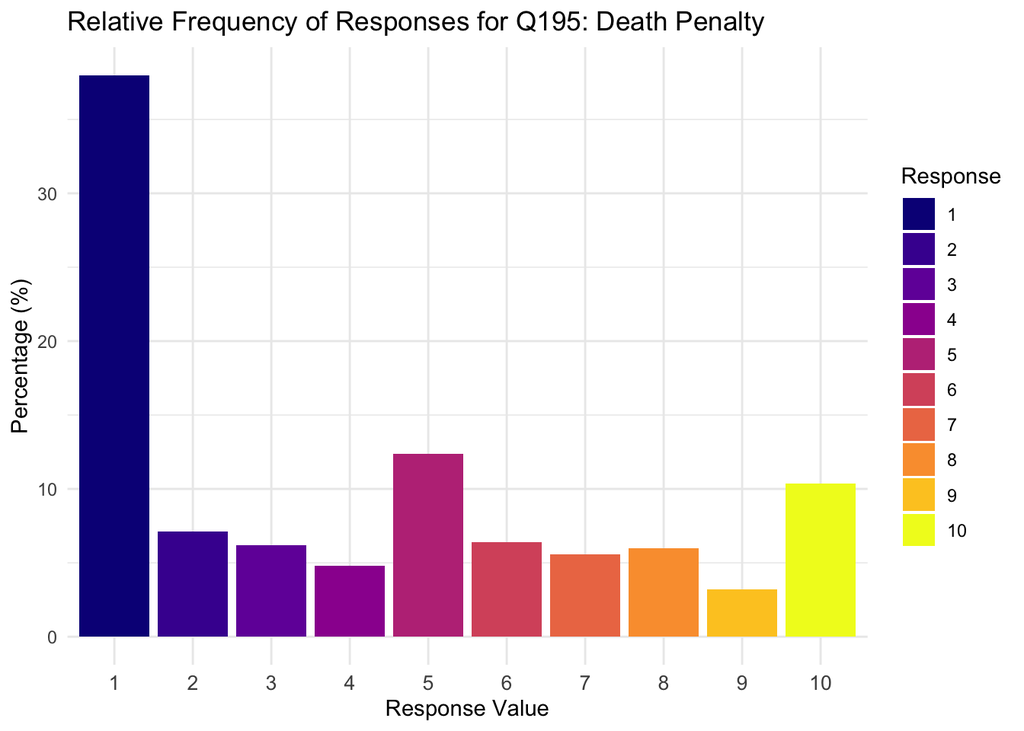

In examining the actions outlined in the World Values Survey, we observe varying levels of justification across different issues. Strong disapproval for actions like claiming unentitled government benefits (Q177) and stealing property (Q179) juxtapose significantly polarised actions, such as homosexuality (Q182), divorce (Q185), and abortion (Q184), likely reflecting cultural and regional differences.

Furthermore, many actions, while semantically aligned, show meaningful differences in societal perception; for instance, Q192 (Terrorism) and Q194 (Political Violence) both relate to violent acts and receive strong rejection, yet political violence demonstrates more variation in opinions compared to terrorism. Similarly, Q189 (wife beating) and Q190 (child beating) show clear condemnation across the dataset, but child beating exhibits more variation than wife beating. The question of euthanasia (Q188) reveals a more divided view, with significant variation in responses. While a substantial portion of respondents express disapproval, a notable minority justifies euthanasia under certain circumstances, leading to greater polarisation in opinions. This contrasts with suicide (Q187), which receives more uniformly negative responses across the dataset.

Overall, certain actions exhibit a clear consensus regarding their unjustifiability, while others reveal substantial variation and polarisation, reflecting the diverse perspectives on controversial issues. These differing viewpoints will be explored further under the section [Are There Regional Differences When It Comes to This?], where we will investigate how and if regional contexts influence the justification of actions across different countries.

## 1.5 Clustering Actions

In the process of determining the level of justification of 19 actions, clustering provides a structured way to group actions based on their justification patterns across the entire population. By applying clustering methods to our research question – “What Actions Can Be Justified? – clustering helps identify broader patterns in moral reasoning and reveals which actions tend to be justified or rejected together.

Following our initial exploratory data analysis, we suggest that the actions listed could be grouped qualitatively into three broad groups; individual liberties, economics/corruption and violent acts. This is also pointed to by the differing average distributions for each question, as evidenced by the skewness values observed in 1.3. We will explore the relationships between the questions first through comparing Spearman correlations, and then Jensen-Shannon Divergence, to better understand possible groupings of actions based on their response patterns.

### 1.5.1 Spearman Correlations

Spearman’s correlation provides a suitable method for clustering the questions into meaningful groups. As a non-parametric approach it does not assume a normal distribution, so is suitable for calculating similarity across our skewed data. It is also appropriate for our likert-type 1-10 justifiability scales, handling ordinal data effectively, and is resistant to outliers.

**Clustering by Spearman Correlation**

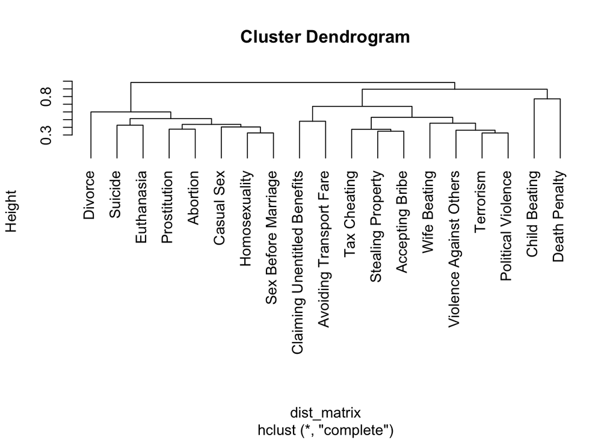

```r
cor_matrix <- cor(wvs_qs[, c("Q177", "Q178", "Q179", "Q180", "Q181",
                           "Q182", "Q183", "Q184", "Q185", "Q186",
                           "Q187", "Q188", "Q189", "Q190", "Q191",
                           "Q192", "Q193", "Q194", "Q195")],
                  method = "spearman",  # Spearman correlation
                    use = "pairwise.complete.obs")

dist_matrix <- as.dist(1 - cor_matrix)

hc <- hclust(dist_matrix, method = "complete")

dend <- as.dendrogram(hc)
dend <- set(dend, "labels", question_labels[labels(dist_matrix)])


plot(hc,
     hang = -1,
     labels = question_labels[labels(dist_matrix)])
```

**Outcome at `k = 4`**

1. Claiming Unentitled Benefits, Avoiding Transport Fare, Stealing Property, Tax Cheating, Accepting Bribe, Wife Beating, Violence Against Others, Terrorism, Political Violence
2. Homosexuality, Prostitution, Abortion, Divorce, Sex Before Marriage, Suicide, Euthanasia, Casual Sex
3. Child Beating
4. Death Penalty

### 1.5.2 Divergence Measures for Clustering

#### Kullback-Leibler Divergence

Kullback-Leibler divergence is a measure of how much a model probability distribution, Q, is different from a true probability distribution, P. In this case, we could pairwise compare two distributions of justification scores and determine similarity or difference, leaving us with clusters which show actions which seem to converge on how justified, unjustified, or polarised respondents are towards them. Jensen-Shannon divergence builds on this, and is discussed below.

#### **Jensen-Shannon Divergence**

Based on the Kullback-Leibler measure, Jensen-Shannon divergence is a symmetric and smoothes version of KL divergence which compares Q and P via an average distribution, M. It has a finite value in the range [0, 1], resulting in it being easier to interpret than KL due to its use of relative entropy. In this case, the similarity of two distributions is greater when the JS distance is closer to zero. Therefore, we have decided to continue with JS divergence, and create a pairwise matrix.

**Generate Probability Distributions for Each Question**

```r
selected_questions <- wvs_long %>%
  filter(response %in% 1:10) %>%  # keep valid response range (1-10)
  group_by(question, response) %>%
  summarise(count = n(), .groups = "drop") %>%
  group_by(question) %>%
  mutate(probability = count / sum(count))  # convert to probability
```

**Computing Jensen-Shannon Divergence**

```r
# unique question pairs
question_list <- unique(wvs_long$question)

# compute pairwise Jensen-Shannon Divergence (JS)
js_results <- expand.grid(Q1 = question_list, Q2 = question_list) %>%
  filter(Q1 != Q2) %>%
  rowwise() %>%
  mutate(JSD = {
    prob_P <- selected_questions %>%
      filter(question == Q1) %>%
      select(response, probability) %>%
      right_join(data.frame(response = 1:10), by = "response") %>%
      replace_na(list(probability = 0)) %>%
      pull(probability)

    prob_Q <- selected_questions %>%
      filter(question == Q2) %>%
      select(response, probability) %>%
      right_join(data.frame(response = 1:10), by = "response") %>%
      replace_na(list(probability = 0)) %>%
      pull(probability)

    # compute Jensen-Shannon Divergence
    JSD(rbind(prob_P, prob_Q), unit = "log2")
  })
```

**Creating a Matrix**

```r
# reshaping js_results into a matrix form
js_matrix <- dcast(js_results, Q1 ~ Q2, value.var = "JSD")

# converting the matrix into a distance object (for clustering)
js_dist <- as.dist(js_matrix[, -1])  # remove the row names (questions themselves)
```

#### (Agglomerative) Hierarchical Clustering w/Jensen-Shannon Divergence

Hierarchical Clustering is a machine learning algorithm that groups data into a tree of clusters. Using the agglomerative method, each question is initially its own cluster and the algorithm merges the two most similar clusters (based on the smallest JS distance), and this is repeated until all questions are in a single cluster, and this is displayed in a dendrogram. Our denogram is displayed below.

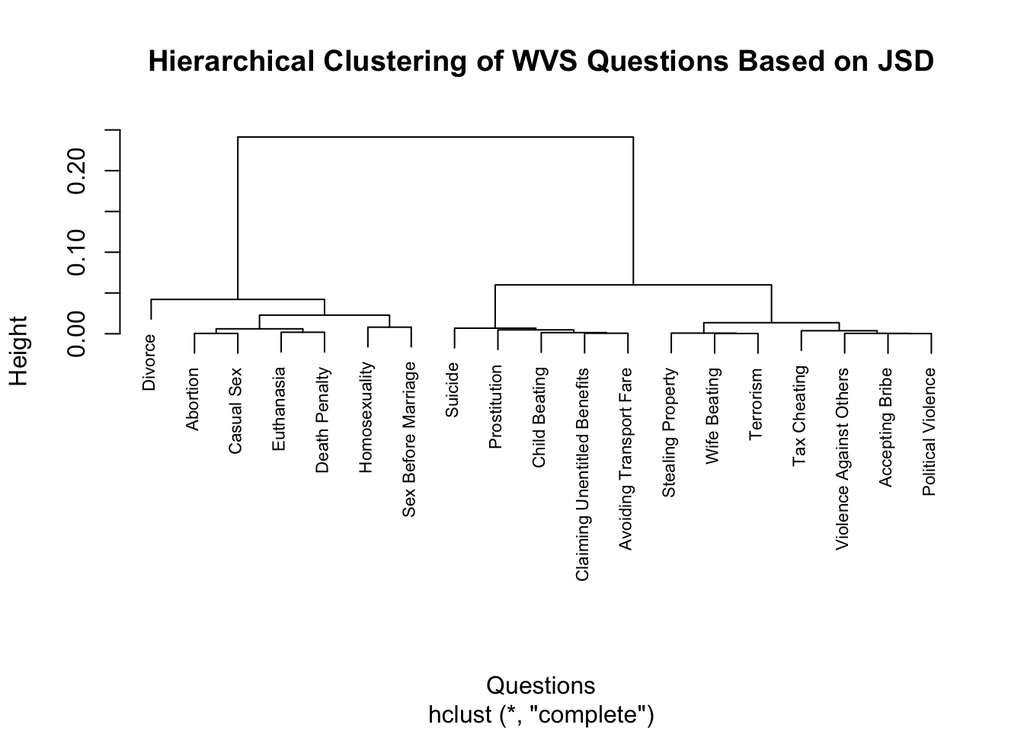

```r
# perform hierarchical clustering using JSD distance matrix
hc <- hclust(js_dist, method = "complete")

# replace default labels (Q177, Q178, ...) with question labels
hc$labels <- question_labels[hc$labels]

# plot the dendrogram with question labels
plot(hc, main = "Hierarchical Clustering of WVS Questions Based on JSD",
     xlab = "Questions", ylab = "Height", cex = 0.7,
     labels = hc$labels)
```

```r
# perform hierarchical clustering
hc <- hclust(js_dist, method = "complete")

# cut the dendrogram into clusters
num_clusters <- 4
clusters <- cutree(hc, k = num_clusters)

# ensure the questions have labels
hc_labels <- names(question_labels)[match(hc$labels, names(question_labels))]
hc$labels <- question_labels[hc_labels]

# create a data frame of the clustered questions
clustered_questions <- data.frame(Question = hc$labels, Cluster = clusters)
```

**Outcome at `k = 4`**

1. Claiming Unentitled Benefits, Avoiding Transport Fare, Prostitution, Suicide, Child Beating
2. Stealing Property, Tax Cheating, Accepting Bribe, Wife Beating, Violence Against Others, Terrorism, Political Violence
3. Homosexuality, Abortion, Sex Before Marriage, Euthanasia, Casual Sex, Death Penalty
4. Divorce